# Offshore Modeling - Manuscript Model

Adam A. Kemberling

2020-04-15

# Manuscript Model

## Model Dataset

### Model Data - West Only

| Region | N |
| --- | --- |
| Texas | 3051 |
| LA West | 3656 |
| MS Bight | 1117 |

- Total Number of Stations = 7824
- Starting in 2000 and continuing through 2018
- Total Sapidus Caught was 5468
- Overall Frequency of Occurrence was 21.2
- Overall Mean Catch Crabs/Hectare: 0.264
- Overall Standard Error 0.018
- Stations with no catch: 6167 / 7824 Stations **or** 78.82%

### East + West

| Region | N |
| --- | --- |
| Texas | 3051 |
| LA West | 3656 |
| MS Bight | 1309 |
| Florida | 2565 |

- Total Number of Stations = 10581
- Starting in 2000 and continuing through 2018
- Total Sapidus Caught was 5554
- Overall Frequency of Occurrence was 16
- Overall Mean Catch Crabs/Hectare: 0.198
- Overall Standard Error 0.013
- Stations with no catch: 8885 / 10581 Stations **or** 83.97%

## Annual Catch and Occurrence

### Data Summary

*NOTE: Contains Data Only from Western-Gulf Subset*

| Survey Year | Stations | Missing Obs | % Occurrence | Mean Catch | SD | Overdispersed |
| --- | --- | --- | --- | --- | --- | --- |
| 2000 | 491 | 0 | 0.1242363 | 0.1434330 | 0.7458628 | yes |
| 2001 | 416 | 0 | 0.1586538 | 0.4066819 | 2.5273291 | yes |
| 2002 | 513 | 0 | 0.2163743 | 0.3070619 | 1.4276630 | yes |
| 2003 | 477 | 0 | 0.2117400 | 0.3260161 | 1.3097278 | yes |
| 2004 | 440 | 0 | 0.1863636 | 0.2700141 | 1.1376114 | yes |
| 2005 | 430 | 0 | 0.3046512 | 0.7326053 | 4.4554998 | yes |
| 2006 | 392 | 0 | 0.2474490 | 0.2941062 | 1.2567796 | yes |
| 2007 | 401 | 0 | 0.2443890 | 0.3713497 | 2.1311305 | yes |
| 2008 | 513 | 0 | 0.1754386 | 0.1034162 | 0.3114427 | no |
| 2009 | 686 | 0 | 0.2172012 | 0.1905500 | 0.6311053 | yes |
| 2010 | 415 | 0 | 0.2554217 | 0.2344566 | 0.6430331 | yes |
| 2011 | 380 | 0 | 0.2842105 | 0.3323709 | 1.0015878 | yes |
| 2012 | 333 | 0 | 0.1561562 | 0.1029894 | 0.3033156 | no |
| 2013 | 274 | 0 | 0.1277372 | 0.0785191 | 0.3293913 | yes |
| 2014 | 349 | 0 | 0.2091691 | 0.2374299 | 1.6983507 | yes |
| 2015 | 350 | 0 | 0.2457143 | 0.2080342 | 0.6744467 | yes |
| 2016 | 322 | 0 | 0.2422360 | 0.1996629 | 0.5809559 | yes |
| 2017 | 335 | 0 | 0.2208955 | 0.2670072 | 0.8739255 | yes |
| 2018 | 307 | 0 | 0.1921824 | 0.1340553 | 0.4087250 | yes |

### Annual Mean Catch

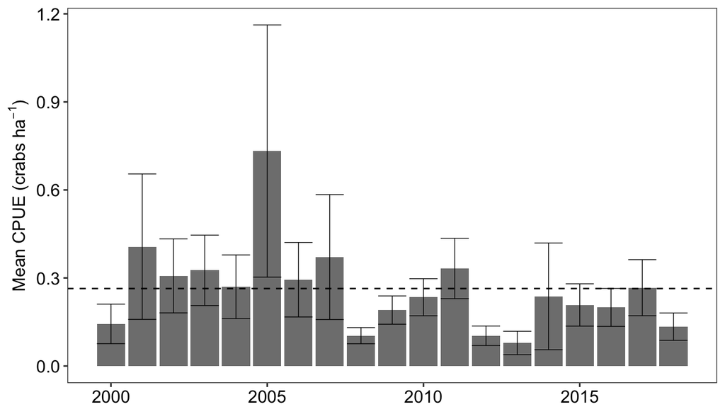

### Annual Frequency of Occurrence

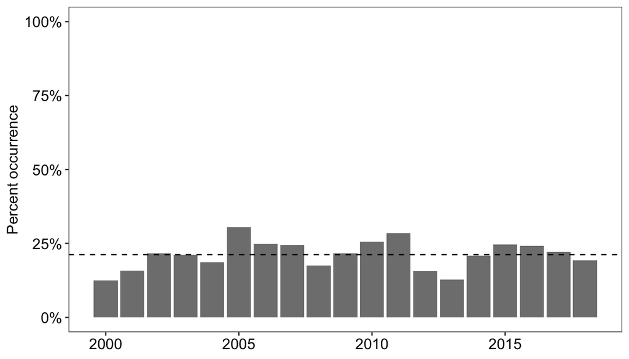

### Side x Side

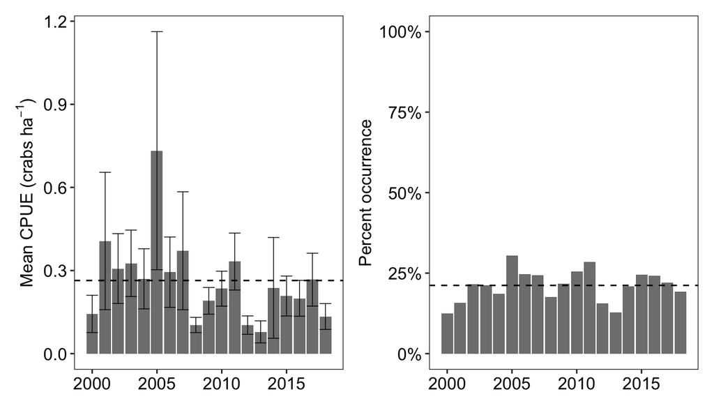

## Region - Season Interactions

*NOTE 2: Mean Catch (per hectare) calculated as the average crabs/hectare from each tow within a region-season grouping. Percent occurrence is calculated separately as the average annual percent occurrence for those same groups.*

### Factor Summary

| Region | Season | Stations | Missing Obs | Mean Catch | SD | Overdispersed |
| --- | --- | --- | --- | --- | --- | --- |
| Texas | Summer | 1559 | 0 | 0.2236771 | 0.9768701 | yes |
| Texas | Fall | 1492 | 0 | 0.1062117 | 1.1289038 | yes |
| LA West | Summer | 1874 | 0 | 0.5495995 | 2.6558490 | yes |
| LA West | Fall | 1782 | 0 | 0.1885071 | 0.9017456 | yes |
| MS Bight | Summer | 561 | 0 | 0.2561072 | 1.0760769 | yes |
| MS Bight | Fall | 556 | 0 | 0.0857699 | 0.3310297 | yes |

Average frequency of occurrence for each region and season is calculated in two steps. In the first step the frequency of occurrence for each region and for both survey seasons is calculated for every year. In the second step those annual means are averaged to get an overall measure for each region for each season, and a measure of error around them is calculated to represent the inter-annual variation in the frequency of occurrence.

| Region | Season | N Years | % Occurrence | % Occurrence SE |
| --- | --- | --- | --- | --- |
| Texas | Summer | 19 | 0.2326514 | 0.0226426 |
| Texas | Fall | 19 | 0.1012512 | 0.0152149 |
| LA West | Summer | 19 | 0.3390328 | 0.0175933 |
| LA West | Fall | 19 | 0.1692615 | 0.0223733 |
| MS Bight | Summer | 19 | 0.2247988 | 0.0341018 |
| MS Bight | Fall | 19 | 0.1329857 | 0.0209576 |

### Mean Catch by Region and Season

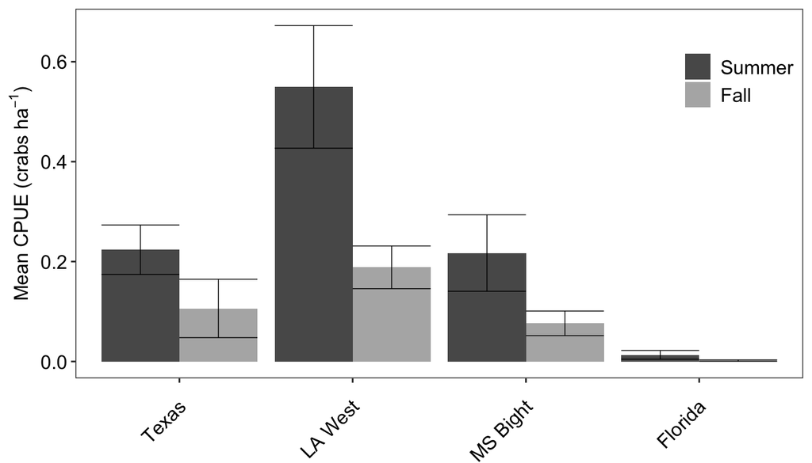

### Frequency of Occurrence

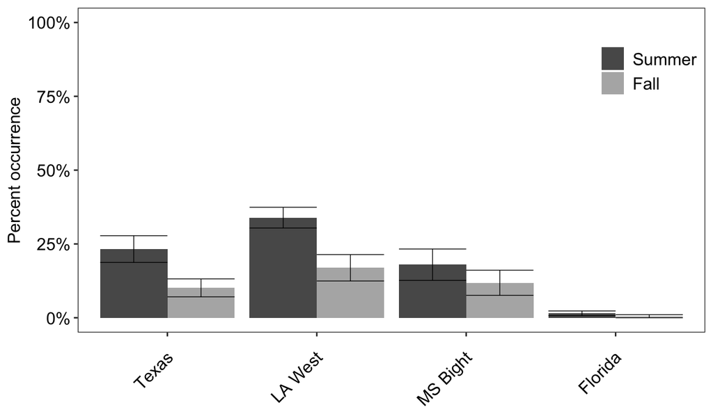

### Side x Side

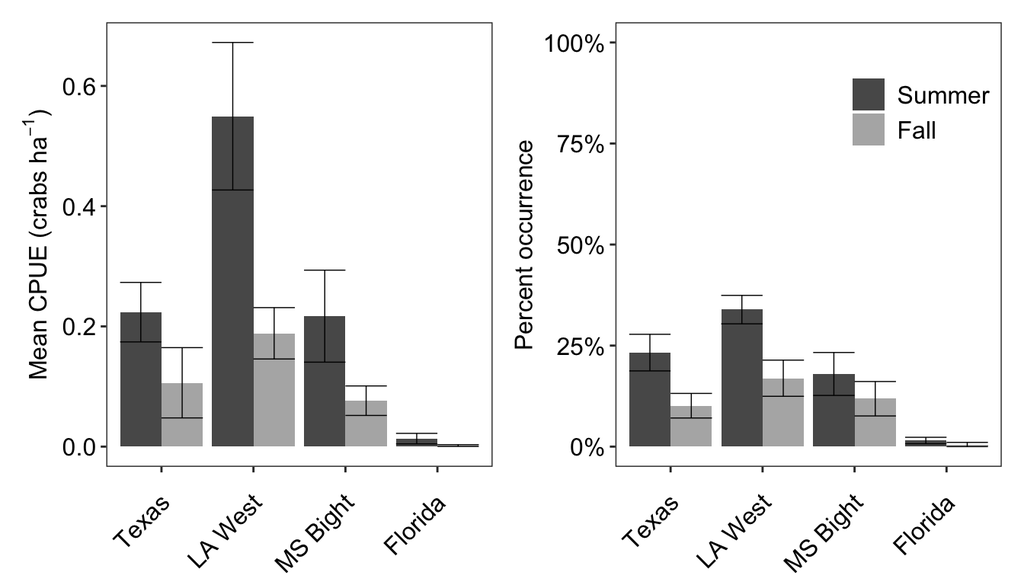

## Candidate Models

### Model Selection using AIC

| Formulation | AIC | Delta AIC |
| --- | --- | --- |
| no interactions | 13813.95 | 250.2686 |
| year * region | 13671.18 | 107.5012 |
| year * season | 13714.15 | 150.4738 |
| region * season | 13814.66 | 250.9788 |
| Year * region & year * season | 13675.07 | 111.3977 |
| all interactions | 13563.68 | 0.0000 |

### Predictor Significance

| Predictor | Df | Deviance | AIC | LRT | Pr(>Chi) |
| --- | --- | --- | --- | --- | --- |
|  | NA | 3943.099 | 13561.68 | NA | NA |
| year_f | 18 | 4030.280 | 13612.86 | 87.18098 | 0.0000000 |
| region | 2 | 3964.300 | 13578.88 | 21.20138 | 0.0000249 |
| season | 1 | 3950.663 | 13567.24 | 7.56352 | 0.0059562 |
| year_f:region | 36 | 4102.296 | 13648.87 | 159.19730 | 0.0000000 |
| year_f:season | 18 | 4032.022 | 13614.60 | 88.92312 | 0.0000000 |
| region:season | 2 | 3963.535 | 13578.11 | 20.43597 | 0.0000365 |

*Percent Deviance Explained by Best Candidate Model:* 22.83

### Model Summary

Statistic reported below is the Wald Chi-Square z-score.

| term | estimate | std.error | statistic | p.value |
| --- | --- | --- | --- | --- |
| (Intercept) | -2.5226968 | 3.318994e-01 | -7.6007882 | 0.0000000 |
| year_f2001 | 1.4475609 | 4.823366e-01 | 3.0011428 | 0.0026897 |
| year_f2002 | 1.2997570 | 4.300605e-01 | 3.0222657 | 0.0025089 |
| year_f2003 | 1.1551077 | 4.338772e-01 | 2.6622921 | 0.0077611 |
| year_f2004 | 0.5951483 | 4.519179e-01 | 1.3169390 | 0.1878591 |
| year_f2005 | 0.8261072 | 4.499882e-01 | 1.8358419 | 0.0663810 |
| year_f2006 | 1.2248743 | 4.363714e-01 | 2.8069538 | 0.0050012 |
| year_f2007 | 0.1928692 | 5.085116e-01 | 0.3792819 | 0.7044785 |
| year_f2008 | -0.0561732 | 4.682622e-01 | -0.1199610 | 0.9045140 |
| year_f2009 | 0.3721793 | 4.157922e-01 | 0.8951087 | 0.3707290 |
| year_f2010 | 1.3678606 | 4.218076e-01 | 3.2428543 | 0.0011834 |
| year_f2011 | 1.6862966 | 4.364890e-01 | 3.8633194 | 0.0001119 |
| year_f2012 | -0.3734306 | 5.004192e-01 | -0.7462355 | 0.4555252 |
| year_f2013 | -1.0190240 | 6.012687e-01 | -1.6947898 | 0.0901153 |
| year_f2014 | 1.7698448 | 4.454852e-01 | 3.9728478 | 0.0000710 |
| year_f2015 | 0.8857008 | 4.505800e-01 | 1.9656906 | 0.0493344 |
| year_f2016 | 1.5388826 | 4.466982e-01 | 3.4450164 | 0.0005710 |
| year_f2017 | 1.4514485 | 4.450963e-01 | 3.2609763 | 0.0011103 |
| year_f2018 | 0.4645462 | 5.119802e-01 | 0.9073519 | 0.3642207 |
| regionLA West | 1.5939088 | 4.110403e-01 | 3.8777434 | 0.0001054 |
| regionMS Bight | -0.5343171 | 6.436653e-01 | -0.8301164 | 0.4064730 |
| seasonFall | -1.6678533 | 6.317096e-01 | -2.6402217 | 0.0082852 |
| year_f2001:regionLA West | -0.0313285 | 6.059282e-01 | -0.0517034 | 0.9587650 |
| year_f2002:regionLA West | -0.7060823 | 5.435910e-01 | -1.2989220 | 0.1939707 |
| year_f2003:regionLA West | -0.3861469 | 5.809924e-01 | -0.6646333 | 0.5062850 |
| year_f2004:regionLA West | -0.1769451 | 5.663152e-01 | -0.3124499 | 0.7546986 |
| year_f2005:regionLA West | 1.0925655 | 5.799504e-01 | 1.8838946 | 0.0595792 |
| year_f2006:regionLA West | -1.1332809 | 5.607124e-01 | -2.0211446 | 0.0432648 |
| year_f2007:regionLA West | -0.4737498 | 6.227672e-01 | -0.7607173 | 0.4468259 |
| year_f2008:regionLA West | -1.3075555 | 5.982034e-01 | -2.1858043 | 0.0288299 |

[output cut: 84 more lines]

### Interaction Plots

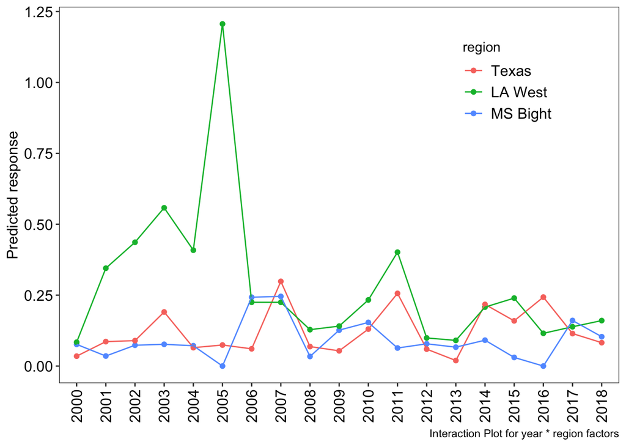

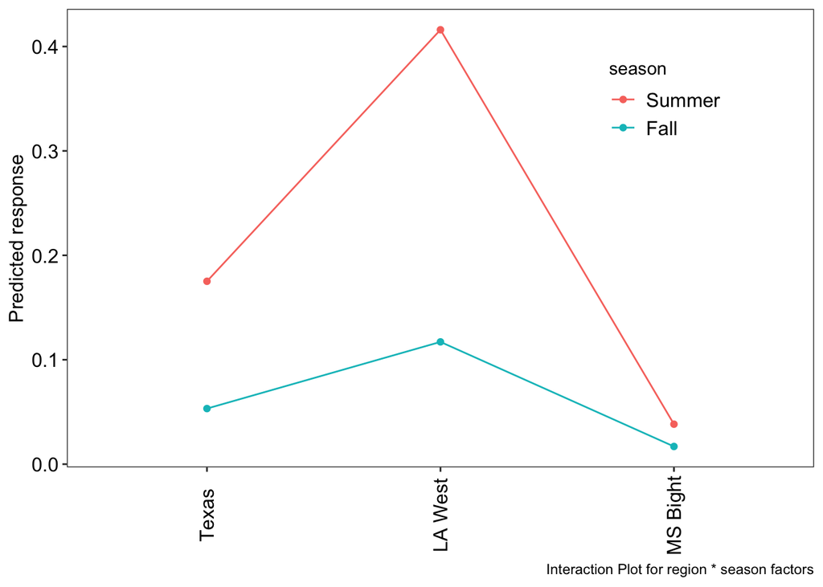

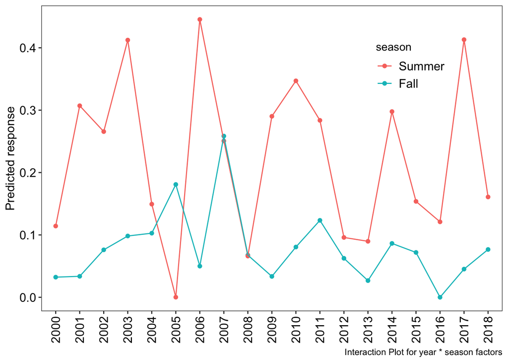

### Tukey HSD multiple comparison test

#### Test 1. Region

```
##
##   Simultaneous Tests for General Linear Hypotheses
##
## Multiple Comparisons of Means: Tukey Contrasts
##
##
## Fit: MASS:::glm.nb(formula = sapidus_catch ~ year_f * region * season +
##     offset(log(area_hectares)), data = seamap_west, init.theta = 0.174655286,
##     link = log)
##
## Linear Hypotheses:
##                         Estimate Std. Error z value Pr(>|z|)
## LA West - Texas == 0      1.5939     0.4110   3.878  < 0.001 ***
## MS Bight - Texas == 0    -0.5343     0.6437  -0.830  0.67838
## MS Bight - LA West == 0  -2.1282     0.6024  -3.533  0.00112 **
## ---
## Signif. codes:  0 '***' 0.001 '**' 0.01 '*' 0.05 '.' 0.1 ' ' 1
## (Adjusted p values reported -- single-step method)
```

```
##
##   Simultaneous Tests for General Linear Hypotheses
##
## Multiple Comparisons of Means: Tukey Contrasts
##
##
## Fit: MASS:::glm.nb(formula = sapidus_catch ~ year_f * region * season +
##     offset(log(area_hectares)), data = seamap_west, init.theta = 0.174655286,
##     link = log)
##
## Linear Hypotheses:
##                    Estimate Std. Error z value Pr(>|z|)
## Fall - Summer == 0  -1.6679     0.6317   -2.64  0.00829 **
## ---
## Signif. codes:  0 '***' 0.001 '**' 0.01 '*' 0.05 '.' 0.1 ' ' 1
## (Adjusted p values reported -- single-step method)
```

## Catch per Hectare Plot

### Seasonal Prediction Differences

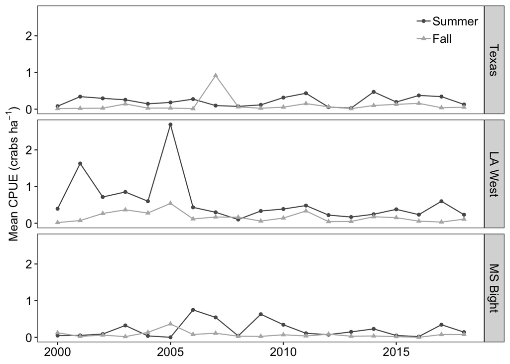

### Observed vs. Predicted Data

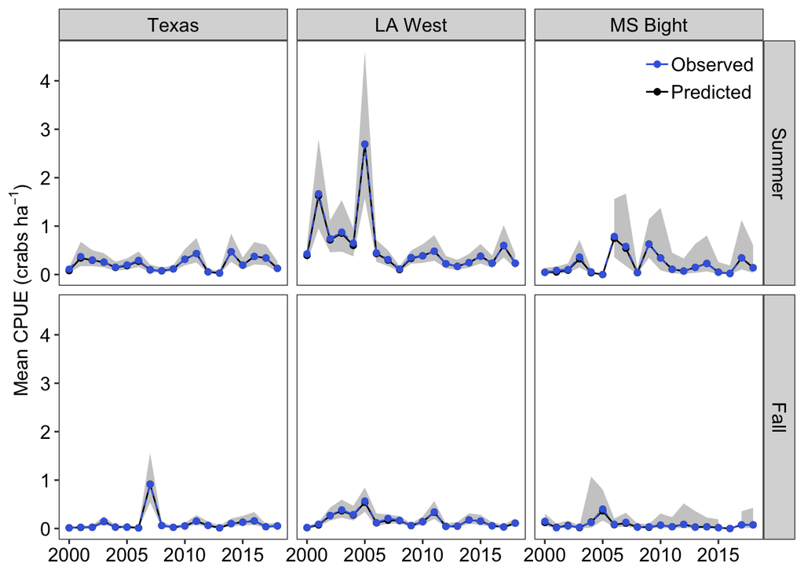

## Raster Plots

### Statistical Zones

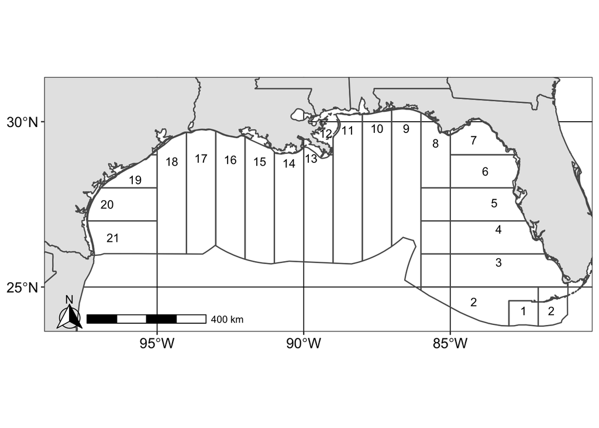

### Sampling Effort

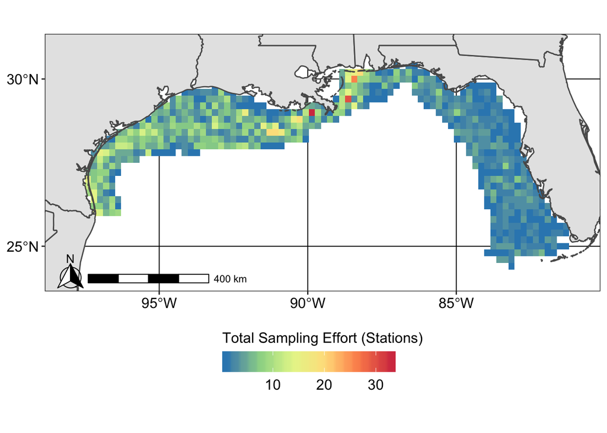

### Catch per Hectare

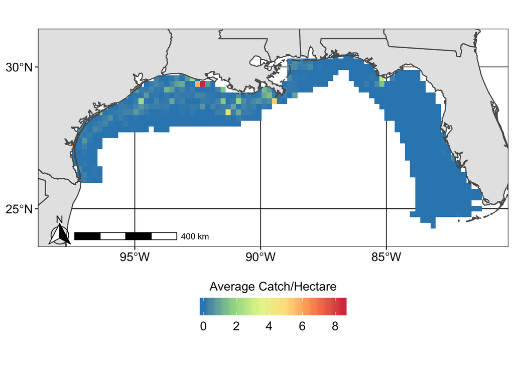

### Variance in CPUE

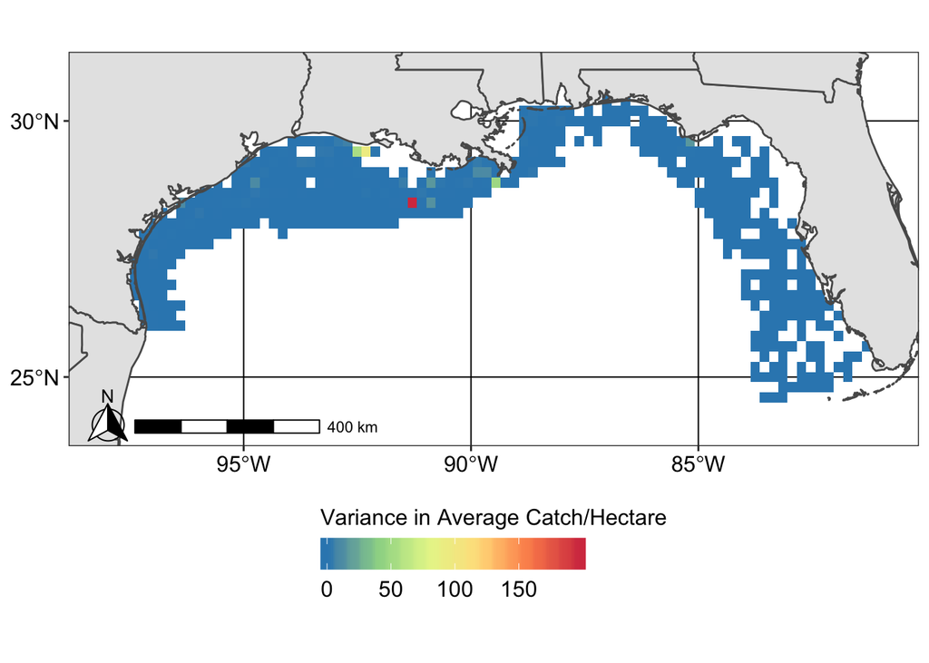

### Total Catch

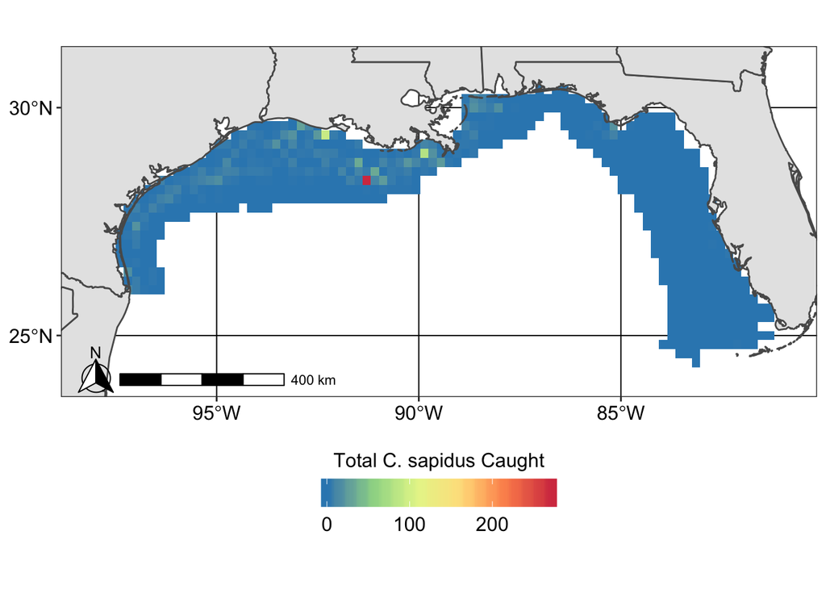